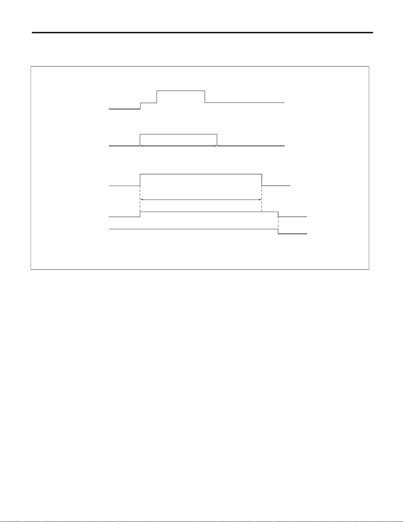

VDC(diag)-24

Warning Light Illumination Pattern

VEHICLE DYNAMICS CONTROL (VDC) (DIAGNOSTICS)

10.Warning Light Illumination Pattern

A: INSPECTION

NOTE:

Hill start assist warning light always illuminates when the hill start assist is in the OFF mode.

(1) Ignition switch (7) Light ON (12) Brake warning light (EBD warning

light)

(2) OFF (8) 2 seconds (13) Parking brake

(3) ON (9) VDC OFF indicator light (14) Released

(4) Engine start (10) VDC warning light & VDC indica-

tor light

(15) Hill start assist warning light

(5) ABS warning light (11) 2 seconds or more (16) VDC traction mode indicator light

(6) Light OFF

VDC01245

[figure not shown]

VDC(diag)-25

Warning Light Illumination Pattern

VEHICLE DYNAMICS CONTROL (VDC) (DIAGNOSTICS)

1) When warning lights or indicator lights do not illuminate in accordance with this illumination pattern, there

must be an electrical malfunction.

2) When the warning lights or indicator lights remain constantly OFF, check the combination meter circuit.

<Ref. to VDC(diag)-28, EBD WARNING LIGHT, ABS WARNING, VDC OFF INDICATOR LIGHT, VDC

WARNING LIGHT AND VDC INDICATOR LIGHT DO NOT COME ON, Warning Light Illumination Pattern.>

<Ref. to VDC(diag)-29, HILL START ASSIST WARNING LIGHT DOES NOT COME ON, Warning Light Illu-

mination Pattern.>

3) When the ABS warning light, VDC OFF indicator light, VDC warning light & VDC indicator light, and hill

start assist warning light do not go off, check the combination meter circuit or CAN communication circuit.

<Ref. to VDC(diag)-30, ABS WARNING LIGHT DOES NOT GO OFF, Warning Light Illumination Pattern.>

<Ref. to VDC(diag)-32, VDC OFF INDICATOR LIGHT DOES NOT GO OFF, Warning Light Illumination Pat-

tern.> <Ref. to VDC(diag)-31, VDC WARNING LIGHT AND VDC INDICATOR LIGHT DO NOT GO OFF,

Warning Light Illumination Pattern.> <Ref. to VDC(diag)-34, HILL START ASSIST WARNING LIGHT DOES

NOT GO OFF, Warning Light Illumination Pattern.>

NOTE:

• Even when the ABS warning light and the VDC warning light & VDC indicator light do not go off in 2 sec-

onds after illuminating, the ABS and VDC functions are normal if the warning lights go off while the vehicle

is driven. However, while these lights are on, the functions with their warning lights illuminated do not oper-

ate.

• It may take several minutes before the VDC warning light & VDC indicator light goes off, if the vehicle is

parked under low temperature for a specified time. This is not defective because it is resulted from low engine

coolant temperature. Perform the Clear Memory Mode because DTC may be recorded at this time. <Ref. to

VDC(diag)-23, Clear Memory Mode.>

• With the vehicle jack-up/lift-up or set on free rollers, when the wheels lock or spin after starting the engine,

ABS warning light, and VDC warning light & VDC indicator light may illuminate because VDCCM&H/U de-

tects the abnormal conditions from ABS wheel speed sensor or longitudinal G sensor. In this case, this is not

a malfunction. Perform the Clear Memory Mode. <Ref. to VDC(diag)-23, Clear Memory Mode.>

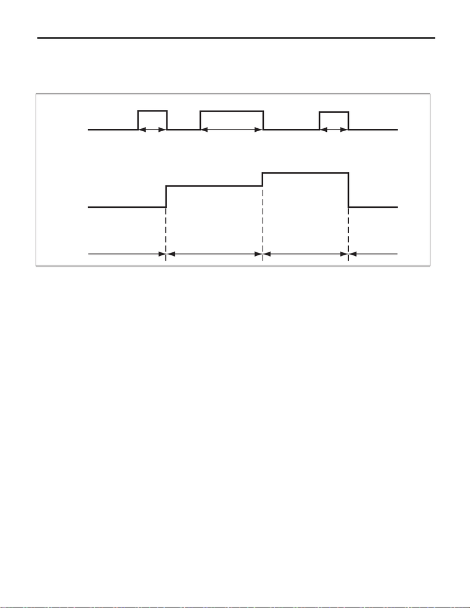

VDC(diag)-26

Warning Light Illumination Pattern

VEHICLE DYNAMICS CONTROL (VDC) (DIAGNOSTICS)

4) Warning light illumination pattern at VDC mode change

If illumination patterns of the VDC OFF indicator light and the VDC traction mode indicator light do not match

the followings when the VDC OFF switch is operated, check the VDC OFF switch circuit, CAN communica-

tion circuit or combination meter circuit. <Ref. to VDC(diag)-38, VDC TRACTION MODE, VDC MODE DOES

NOT CHANGE, Warning Light Illumination Pattern.>

(1) VDC OFF switch (6) VDC OFF indicator light and VDC

traction mode indicator light

(10) VDC mode

(2) OFF (7) Light OFF (11) Normal mode

(3) ON (8) VDC OFF indicator light and VDC

traction mode indicator light ON

(12) Traction mode

(4) Less than 2 seconds (9) VDC OFF indicator light ON

VDC traction mode indicator light

OFF

(13) OFF mode

(5) 2 seconds or more and less than

30 seconds

VDC00595

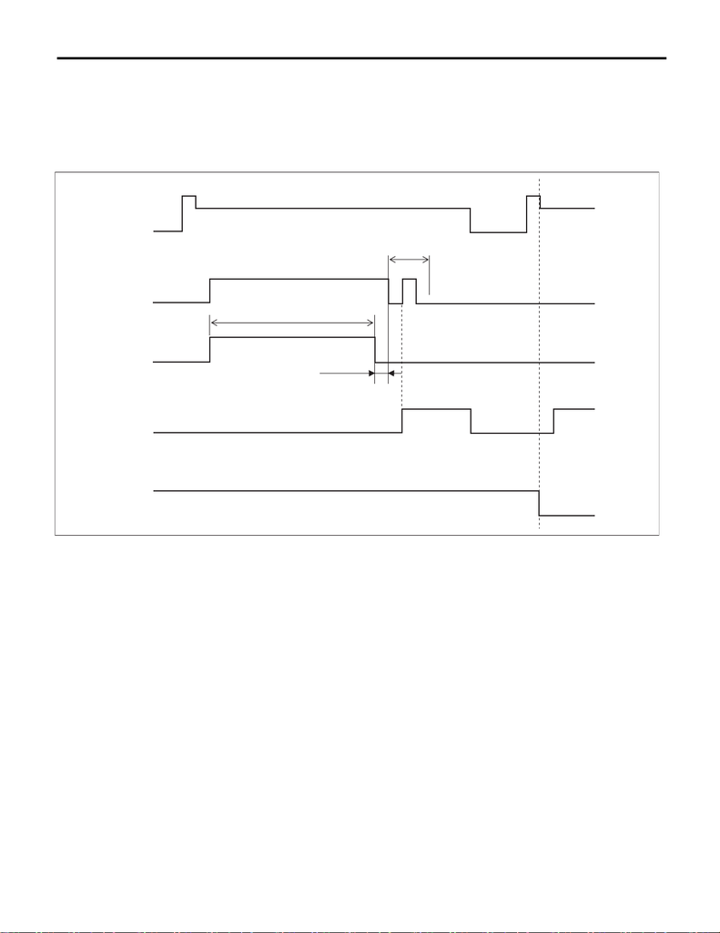

VDC(diag)-27

Warning Light Illumination Pattern

VEHICLE DYNAMICS CONTROL (VDC) (DIAGNOSTICS)

5) Warning light illumination pattern at hill start assist OFF mode change

When the VDC OFF switch is kept pressed, VDC OFF indicator light illuminates, then goes off in approx. 30

seconds. If the switch is released in 5 seconds after the light goes off then pressed again in 2 seconds, hill

start assist warning light illuminates then mode is changed to hill start assist OFF mode. If hill start assist

function ON/OFF does not change, check VDC OFF switch circuit, CAN communication circuit or combina-

tion meter circuit. <Ref. to VDC(diag)-40, HILL START ASSIST ON/OFF MODE, VDC MODE DOES NOT

CHANGE, Warning Light Illumination Pattern.>

NOTE:

Hill start assist warning light always illuminates to inform that the hill start assist does not operate during hill

start assist OFF mode.

(1) Ignition key (6) Less than 2 seconds (10) 5 seconds or less

(2) OFF (7) VDC OFF indicator light (11) Hill start assist warning light

(3) Start (8) Approx. 30 seconds (until (7) goes

off)

(12) Light ON

(4) ON (9) Light ON (13) Hill start assist function

(5) VDC OFF switch

VDC00689

[figure not shown]

VDC(diag)-28

Warning Light Illumination Pattern

VEHICLE DYNAMICS CONTROL (VDC) (DIAGNOSTICS)

B: EBD WARNING LIGHT, ABS WARNING, VDC OFF INDICATOR LIGHT, VDC

WARNING LIGHT AND VDC INDICATOR LIGHT DO NOT COME ON

DETECTING CONDITION:

Defective combination meter

TROUBLE SYMPTOM:

When the ignition switch is turned to ON (engine OFF), EBD warning light, ABS warning light, VDC OFF in-

dicator light, and VDC warning light & VDC indicator light do not illuminate.

NOTE:

When pressing the VDC OFF switch for 30 seconds or more, the VDC OFF indicator light goes off and cannot

operate any more. When turning the ignition switch from OFF to ON, the OFF operation enabled status is re-

stored.

Step Check Yes No

1 CHECK OTHER INDICATOR LIGHT.

Turn the ignition switch to ON.

Does other indicator light illumi-

nate soon after “ON”?

Go to step 2. Check the combi-

nation meter. <Ref.

to IDI-6, SELF-

DIAGNOSIS DIS-

PLAY MODE,

OPERATION,

Combination Meter

System.>

2 CHECK VDCCM.

When the engine does not start, display the cur-

rent data of VDCCM using Subaru Select Mon-

itor.

Immediately after the ignition

switch is turned to ON, is the

«EBD Warning Light» ON?

Go to step 3. Replace the

VDCCM&H/U.

<Ref. to VDC-8,

VDC Control Mod-

ule and Hydraulic

Control Unit

(VDCCM&H/U).>

3 CHECK VDCCM.

When the engine does not start, display the cur-

rent data of VDCCM using Subaru Select Mon-

itor.

Immediately after the ignition

switch is turned to ON, is the

«ABS Warning Lamp» ON?

Go to step 4. Replace the

VDCCM&H/U.

<Ref. to VDC-8,

VDC Control Mod-

ule and Hydraulic

Control Unit

(VDCCM&H/U).>

4 CHECK VDCCM.

When the engine does not start, display the cur-

rent data of VDCCM using Subaru Select Mon-

itor.

Immediately after the ignition

switch is turned to ON, is the

«VDC Warning Lamp» ON?

Check the combi-

nation meter. <Ref.

to IDI-6, SELF-

DIAGNOSIS DIS-

PLAY MODE,

OPERATION,

Combination Meter

System.>

Replace the

VDCCM&H/U.

<Ref. to VDC-8,

VDC Control Mod-

ule and Hydraulic

Control Unit

(VDCCM&H/U).>

[figure not shown]

VDC(diag)-29

Warning Light Illumination Pattern

VEHICLE DYNAMICS CONTROL (VDC) (DIAGNOSTICS)

C: HILL START ASSIST WARNING LIGHT DOES NOT COME ON

DETECTING CONDITION:

Defective combination meter

TROUBLE SYMPTOM:

When the ignition switch is turned to ON (engine OFF), hill start assist warning light does not illuminate.

Step Check Yes No

1 CHECK OTHER INDICATOR LIGHT.

Turn the ignition switch to ON. (engine OFF)

Do other indicator lights illumi-

nate?

Go to step 2. Check the combi-

nation meter. <Ref.

to IDI-6, SELF-

DIAGNOSIS DIS-

PLAY MODE,

OPERATION,

Combination Meter

System.>

2 READ DTC.

Read the DTC. <Ref. to VDC(diag)-21, Read

Diagnostic Trouble Code (DTC).>

Is DTC displayed? Perform the diag-

nosis according to

DTC. <Ref. to

VDC(diag)-42, List

of Diagnostic Trou-

ble Code (DTC).>

Go to step 3.

3 CHECK LAN SYSTEM.

Perform the diagnosis for LAN system. <Ref. to

LAN(diag)-2, Basic Diagnostic Procedure.>

Is there any fault in LAN sys-

tem?

Perform the diag-

nosis according to

DTC for LAN sys-

tem. <Ref. to

LAN(diag)-70, List

of Diagnostic Trou-

ble Code (DTC).>

Go to step 4.

4 CHECK COMBINATION METER.

Check the combination meter. <Ref. to IDI-6,

SELF-DIAGNOSIS DISPLAY MODE, OPERA-

TION, Combination Meter System.>

Is combination meter OK? Replace the

VDCCM&H/U.

<Ref. to VDC-8,

VDC Control Mod-

ule and Hydraulic

Control Unit

(VDCCM&H/U).>

Replace the com-

bination meter.

<Ref. to IDI-13,

Combination

Meter.>

[figure not shown]

VDC(diag)-30

Warning Light Illumination Pattern

VEHICLE DYNAMICS CONTROL (VDC) (DIAGNOSTICS)

D: ABS WARNING LIGHT DOES NOT GO OFF

DETECTING CONDITION:

• Defective combination meter

• Defective engine

• Defective CAN communication

TROUBLE SYMPTOM:

When starting the engine, the ABS warning light is kept on.

Step Check Yes No

1 READ DTC.

Read the DTC. <Ref. to VDC(diag)-21, Read

Diagnostic Trouble Code (DTC).>

Is DTC displayed? Perform the diag-

nosis according to

DTC. <Ref. to

VDC(diag)-42, List

of Diagnostic Trou-

ble Code (DTC).>

Go to step 2.

2 CHECK VDCCM.

Display the current data of VDCCM using Sub-

aru Select Monitor.

Is the «ABS Warning Lamp»

ON?

Go to step 3. Go to step 5.

3 CHECK WARNING LIGHT.

1) Save the freeze frame data.

2) Perform the Clear Memory Mode. <Ref. to

VDC(diag)-23, Clear Memory Mode.>

Does the ABS warning light go

off?

Normal Perform

the Inspection

Mode to check that

the light does not

turn ON again.

Go to step 4.

4 READ DTC.

Read the DTC after driving the vehicle at 40 km/h

(25 MPH) or more.

Is DTC displayed? Perform the diag-

nosis according to

DTC. <Ref. to

VDC(diag)-42, List

of Diagnostic Trou-

ble Code (DTC).>

Go to step 5.

5 CHECK LAN SYSTEM.

Perform the diagnosis for LAN system. <Ref. to

LAN(diag)-2, Basic Diagnostic Procedure.>

Is there any fault in LAN sys-

tem?

Perform the diag-

nosis according to

DTC for LAN sys-

tem. <Ref. to

LAN(diag)-70, List

of Diagnostic Trou-

ble Code (DTC).>

Go to step 6.

6 CHECK COMBINATION METER.

Check the combination meter. <Ref. to IDI-6,

SELF-DIAGNOSIS DISPLAY MODE, OPERA-

TION, Combination Meter System.>

Is combination meter OK? Replace the

VDCCM&H/U.

<Ref. to VDC-8,

VDC Control Mod-

ule and Hydraulic

Control Unit

(VDCCM&H/U).>

Replace the com-

bination meter.

<Ref. to IDI-13,

REMOVAL, Com-

bination Meter.>

[figure not shown]

VDC(diag)-31

Warning Light Illumination Pattern

VEHICLE DYNAMICS CONTROL (VDC) (DIAGNOSTICS)

E: VDC WARNING LIGHT AND VDC INDICATOR LIGHT DO NOT GO OFF

DETECTING CONDITION:

• Defective combination meter

• Defective engine

• Defective CAN communication

TROUBLE SYMPTOM:

When starting the engine, the VDC warning light & VDC indicator light remains lit.

Step Check Yes No

1 READ DTC.

Read the DTC. <Ref. to VDC(diag)-21, Read

Diagnostic Trouble Code (DTC).>

Is DTC displayed? Perform the diag-

nosis according to

DTC. <Ref. to

VDC(diag)-42, List

of Diagnostic Trou-

ble Code (DTC).>

Go to step 2.

2 CHECK VDCCM.

Display the current data of VDCCM using Sub-

aru Select Monitor.

Is the «VDC Warning Lamp»

ON?

Go to step 3. Go to step 5.

3 CHECK WARNING LIGHT.

1) Save the freeze frame data.

2) Perform the Clear Memory Mode. <Ref. to

VDC(diag)-23, Clear Memory Mode.>

Does the VDC warning light &

VDC operation indicator light

go off?

Normal Perform

the Inspection

Mode to check that

the light does not

turn ON again.

Go to step 4.

4 READ DTC.

Read the DTC after driving the vehicle at 40 km/h

(25 MPH) or more.

Is DTC displayed? Perform the diag-

nosis according to

DTC. <Ref. to

VDC(diag)-42, List

of Diagnostic Trou-

ble Code (DTC).>

Go to step 5.

5 CHECK LAN SYSTEM.

Perform the diagnosis for LAN system. <Ref. to

LAN(diag)-2, Basic Diagnostic Procedure.>

Is there any fault in LAN sys-

tem?

Perform the diag-

nosis according to

DTC for LAN sys-

tem. <Ref. to

LAN(diag)-70, List

of Diagnostic Trou-

ble Code (DTC).>

Go to step 6.

6 CHECK COMBINATION METER.

Check the combination meter. <Ref. to IDI-6,

SELF-DIAGNOSIS DISPLAY MODE, OPERA-

TION, Combination Meter System.>

Is combination meter OK? Replace the

VDCCM&H/U.

<Ref. to VDC-8,

VDC Control Mod-

ule and Hydraulic

Control Unit

(VDCCM&H/U).>

Replace the com-

bination meter.

<Ref. to IDI-13,

REMOVAL, Com-

bination Meter.>

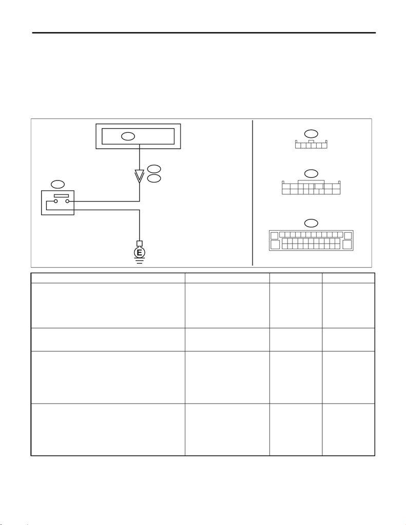

VDC(diag)-32

Warning Light Illumination Pattern

VEHICLE DYNAMICS CONTROL (VDC) (DIAGNOSTICS)

F: VDC OFF INDICATOR LIGHT DOES NOT GO OFF

DETECTING CONDITION:

• Defective combination meter

• Defective CAN communication

• VDC OFF switch is shorted.

TROUBLE SYMPTOM:

When starting the engine, VDC OFF indicator light is kept ON.

WIRING DIAGRAM:

Vehicle dynamics control system <Ref. to WI-412, Vehicle Dynamics Control System.>

Step Check Yes No

1 READ DTC.

Read the DTC. <Ref. to VDC(diag)-21, Read

Diagnostic Trouble Code (DTC).>

Is DTC displayed? Perform the diag-

nosis according to

DTC. <Ref. to

VDC(diag)-42, List

of Diagnostic Trou-

ble Code (DTC).>

Go to step 2.

2 CHECK VDC OFF SWITCH.

Remove and check VDC OFF switch. <Ref. to

VDC-36, VDC OFF Switch.>

Is the VDC OFF switch normal? Go to step 3. Replace the VDC

OFF switch.

3 CHECK VDC OFF SWITCH CIRCUIT.

1) Disconnect the connector from the

VDCCM&H/U.

2) Measure the resistance between

VDCCM&H/U connector and chassis ground.

Connector & terminal

(B310) No. 21 — Chassis ground:

Is the resistance less than 10

Ω?

Check the VDC

OFF switch circuit.

Go to step 4.

4 CHECK LAN SYSTEM.

Perform the diagnosis for LAN system. <Ref. to

LAN(diag)-2, Basic Diagnostic Procedure.>

Is there any fault in LAN sys-

tem?

Perform the diag-

nosis according to

DTC for LAN sys-

tem. <Ref. to

LAN(diag)-70, List

of Diagnostic Trou-

ble Code (DTC).>

Go to step 5.

VDC01283

[figure not shown]

VDC(diag)-33

Warning Light Illumination Pattern

VEHICLE DYNAMICS CONTROL (VDC) (DIAGNOSTICS)

5 CHECK COMBINATION METER.

Check the combination meter. <Ref. to IDI-6,

SELF-DIAGNOSIS DISPLAY MODE, OPERA-

TION, Combination Meter System.>

Is combination meter OK? Replace the

VDCCM&H/U.

<Ref. to VDC-8,

VDC Control Mod-

ule and Hydraulic

Control Unit

(VDCCM&H/U).>

Replace the com-

bination meter.

<Ref. to IDI-13,

REMOVAL, Com-

bination Meter.>

Step Check Yes No

[figure not shown]

VDC(diag)-34

Warning Light Illumination Pattern

VEHICLE DYNAMICS CONTROL (VDC) (DIAGNOSTICS)

G: HILL START ASSIST WARNING LIGHT DOES NOT GO OFF

DETECTING CONDITION:

• Defective combination meter

• Defective CAN communication

TROUBLE SYMPTOM:

When starting the engine, the hill start assist warning light continues to illuminate.

Step Check Yes No

1 CHECK HILL START ASSIST MODE. Is the hill start assist OFF? Normal Go to step 2.

2 READ DTC.

Read the DTC. <Ref. to VDC(diag)-21, Read

Diagnostic Trouble Code (DTC).>

Is DTC displayed? Perform the diag-

nosis according to

DTC. <Ref. to

VDC(diag)-42, List

of Diagnostic Trou-

ble Code (DTC).>

Go to step 3.

3 CHECK LAN SYSTEM.

Perform the diagnosis for LAN system. <Ref. to

LAN(diag)-2, Basic Diagnostic Procedure.>

Is there any fault in LAN sys-

tem?

Perform the diag-

nosis according to

DTC for LAN sys-

tem. <Ref. to

LAN(diag)-70, List

of Diagnostic Trou-

ble Code (DTC).>

Go to step 4.

4 CHECK COMBINATION METER.

Check the combination meter. <Ref. to IDI-6,

SELF-DIAGNOSIS DISPLAY MODE, OPERA-

TION, Combination Meter System.>

Is combination meter OK? Replace the

VDCCM&H/U.

<Ref. to VDC-8,

VDC Control Mod-

ule and Hydraulic

Control Unit

(VDCCM&H/U).>

Replace the com-

bination meter.

<Ref. to IDI-13,

REMOVAL, Com-

bination Meter.>

[figure not shown]

VDC(diag)-35

Warning Light Illumination Pattern

VEHICLE DYNAMICS CONTROL (VDC) (DIAGNOSTICS)

H: BRAKE WARNING LIGHT DOES NOT GO OFF

DETECTING CONDITION:

• Brake warning light circuit is shorted.

• Defective sensor/connector

• Defective CAN communication

TROUBLE SYMPTOM:

After starting the engine, the brake warning light remains lit though the parking lever is released.

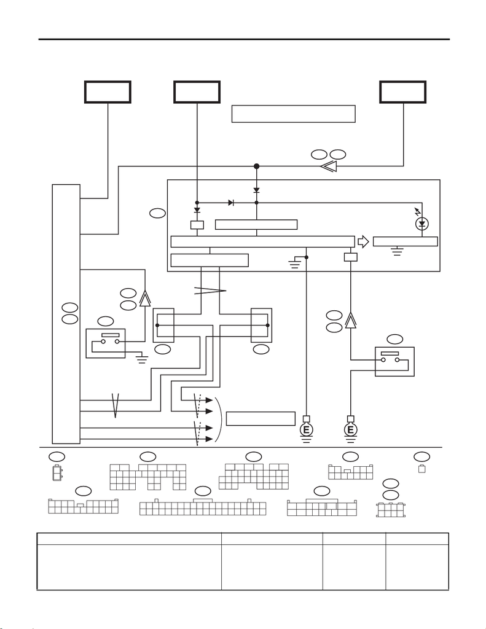

VDC(diag)-36

Warning Light Illumination Pattern

VEHICLE DYNAMICS CONTROL (VDC) (DIAGNOSTICS)

WIRING DIAGRAM:

Parking brake / brake fluid level warning light system <Ref. to WI-320, Parking Brake / Brake Fluid Level

Warning Light System.>

Step Check Yes No

1 CHECK INSTALLATION OF VDCCM&H/U

CONNECTOR.

1) Turn the ignition switch to OFF.

2) Check that the VDCCM&H/U connector is

inserted until it is locked by clamp.

Is the connector firmly

inserted?

Go to step 2. Insert the

VDCCM&H/U con-

nector until it is

locked by clamp.

VDC01284

[figure not shown]

VDC(diag)-37

Warning Light Illumination Pattern

VEHICLE DYNAMICS CONTROL (VDC) (DIAGNOSTICS)

2 READ DTC.

Read the DTC. <Ref. to VDC(diag)-21, Read

Diagnostic Trouble Code (DTC).>

Is DTC displayed? Perform the diag-

nosis according to

DTC. <Ref. to

VDC(diag)-42, List

of Diagnostic Trou-

ble Code (DTC).>

Go to step 3.

3 CHECK BRAKE FLUID AMOUNT.

Check the amount of brake fluid in the reservoir

tank of master cylinder.

Does the level of the brake fluid

amount fall between the lines of

“MAX” and “MIN”?

Go to step 4. Replenish brake

fluid to the speci-

fied value.

4 CHECK BRAKE FLUID LEVEL SWITCH.

1) Turn the ignition switch to OFF.

2) Disconnect the level switch connector (B16)

from master cylinder.

3) Measure the resistance of master cylinder

terminals.

Terminals

No. 1 — No. 2:

Is the resistance 1 MΩ or

more?

Go to step 5. Replace the mas-

ter cylinder. <Ref.

to BR-52, Master

Cylinder.>

5 CHECK GROUND SHORT OF HARNESS.

1) Disconnect the connector (i10) from combi-

nation meter.

2) Measure the resistance between combina-

tion meter connector and chassis ground.

Connector & terminal

(i10) No. 23 — Chassis ground:

Is the resistance 1 MΩ or

more?

Go to step 6. Repair the harness

between combina-

tion meter and

brake fluid level

switch.

6 CHECK PARKING BRAKE SWITCH.

1) Disconnect the connector (R4) from parking

brake switch.

2) Release the parking brake.

3) Measure the resistance between parking

brake switch terminal and chassis ground.

Is the resistance 1 MΩ or

more?

Go to step 7. Replace the park-

ing brake switch.

7 CHECK GROUND SHORT OF HARNESS.

1) Disconnect the connector (i84) from body

integrated unit.

2) Measure the resistance between body inte-

grated unit connector and chassis ground.

Connector & terminal

(i84) No. 32 — Chassis ground:

Is the resistance 1 MΩ or

more?

Go to step 8. Repair the harness

between body inte-

grated unit and

parking brake

switch.

8 CHECK POOR CONTACT OF CONNECTOR.

Check for poor contact of all connectors.

Is there poor contact? Repair the connec-

tor.

Go to step 9.

9 CHECK LAN SYSTEM.

Perform the diagnosis for LAN system. <Ref. to

LAN(diag)-2, Basic Diagnostic Procedure.>

Is there any fault in LAN sys-

tem?

Perform the diag-

nosis according to

DTC for LAN sys-

tem. <Ref. to

LAN(diag)-70, List

of Diagnostic Trou-

ble Code (DTC).>

Go to step 10.

10 CHECK COMBINATION METER.

Check the combination meter. <Ref. to IDI-6,

SELF-DIAGNOSIS DISPLAY MODE, OPERA-

TION, Combination Meter System.>

Is combination meter OK? Replace the

VDCCM&H/U.

<Ref. to VDC-8,

VDC Control Mod-

ule and Hydraulic

Control Unit

(VDCCM&H/U).>

Replace the com-

bination meter.

<Ref. to IDI-13,

Combination

Meter.>

Step Check Yes No

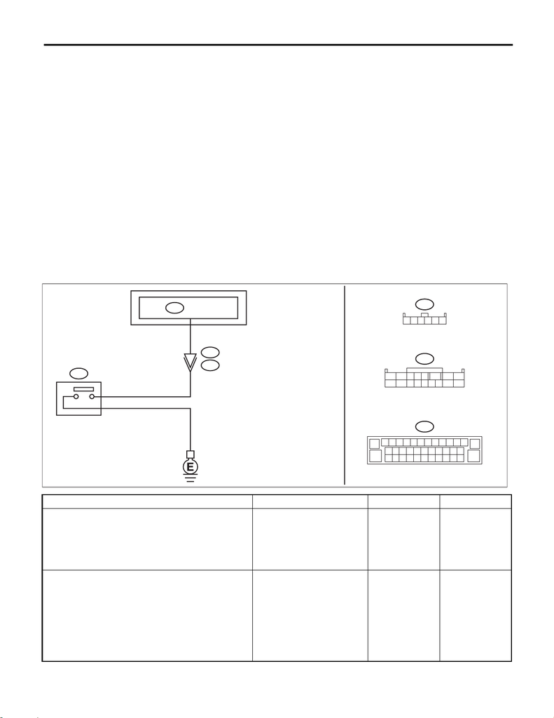

VDC(diag)-38

Warning Light Illumination Pattern

VEHICLE DYNAMICS CONTROL (VDC) (DIAGNOSTICS)

I: VDC MODE DOES NOT CHANGE

1. VDC TRACTION MODE

DETECTING CONDITION

• Defective combination meter

• Defective CAN communication

• Defective VDC OFF switch

TROUBLE SYMPTOM:

Even when the VDC OFF switch is operated, the VDC traction mode indicator light does not illuminate, or the

illumination color does not change. (The VDC mode does not change)

NOTE:

• When the VDC OFF switch is pressed (2 seconds or less), the VDC traction mode indicator light illumi-

nates in green. (Traction mode)

the OFF operation enabled status is restored.

WIRING DIAGRAM:

Vehicle dynamics control system <Ref. to WI-412, Vehicle Dynamics Control System.>

Step Check Yes No

1 READ DTC.

Read the DTC. <Ref. to VDC(diag)-21, Read

Diagnostic Trouble Code (DTC).>

Is DTC displayed? Perform the diag-

nosis according to

DTC. <Ref. to

VDC(diag)-42, List

of Diagnostic Trou-

ble Code (DTC).>

Go to step 2.

2 CHECK HARNESS.

1) Turn the ignition switch to OFF.

2) Disconnect the connector from the

VDCCM&H/U and VDC OFF switch.

3) Measure the resistance of harness between

the VDCCM&H/U and VDC OFF switch con-

nectors.

Connector & terminal

(B310) No. 21 — (i234) No. 5:

Is the resistance less than 1 Ω? Go to step 3. Repair the harness

between the

VDCCM&H/U and

VDC OFF switch

connectors.

VDC01283

[figure not shown]

VDC(diag)-39

Warning Light Illumination Pattern

VEHICLE DYNAMICS CONTROL (VDC) (DIAGNOSTICS)

3 CHECK GROUND SHORT OF HARNESS.

Measure the resistance between VDCCM&H/U

connector and chassis ground.

Connector & terminal

(B310) No. 21 — Chassis ground:

Is the resistance 1 MΩ or

more?

Go to step 4. Repair the harness

between the

VDCCM&H/U and

VDC OFF switch

connectors.

4 CHECK HARNESS.

Measure the resistance of harness between

VDC OFF switch connector and chassis

ground.

Connector & terminal

(i234) No. 6 — Chassis ground:

Is the resistance less than 10

Ω?

Go to step 5. Repair the harness

between the VDC

OFF switch con-

nector and chassis

ground.

5 CHECK VDC OFF SWITCH.

Check the VDC OFF switch. <Ref. to VDC-37,

INSPECTION, VDC OFF Switch.>

Is the VDC OFF switch normal? Go to step 6. Replace the VDC

OFF switch. <Ref.

to VDC-36, VDC

OFF Switch.>

6 CHECK LAN SYSTEM.

Perform the diagnosis for LAN system. <Ref. to

LAN(diag)-2, Basic Diagnostic Procedure.>

Is there any fault in LAN sys-

tem?

Perform the diag-

nosis according to

DTC for LAN sys-

tem. <Ref. to

LAN(diag)-70, List

of Diagnostic Trou-

ble Code (DTC).>

Go to step 7.

7 CHECK COMBINATION METER.

Check the combination meter. <Ref. to IDI-9,

INSPECTION, Combination Meter System.>

Is combination meter OK? Replace the

VDCCM&H/U.

<Ref. to VDC-8,

VDC Control Mod-

ule and Hydraulic

Control Unit

(VDCCM&H/U).>

Replace the com-

bination meter.

<Ref. to IDI-13,

Combination

Meter.>

Step Check Yes No

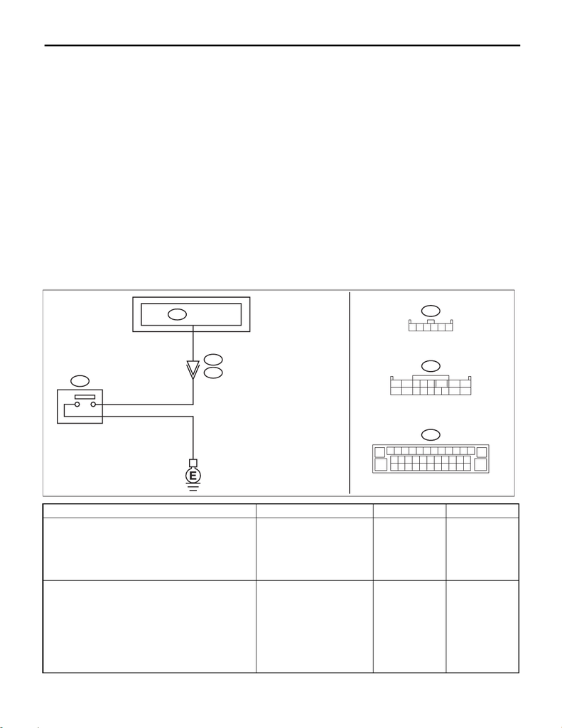

VDC(diag)-40

Warning Light Illumination Pattern

VEHICLE DYNAMICS CONTROL (VDC) (DIAGNOSTICS)

2. HILL START ASSIST ON/OFF MODE

DETECTING CONDITION

• Defective combination meter

• Defective CAN communication

• Defective VDC OFF switch

TROUBLE SYMPTOM:

Hill start assist warning light does not illuminate or go off when hill start assist function ON/OFF is changed.

(Hill start assist mode does not change.)

NOTE:

• When the VDC OFF switch is kept pressed, the VDC traction mode indicator light illuminates in green at

first, then turns yellow, and then goes off in approx. 30 seconds. If the switch is released in 5 seconds after

the light goes off then pressed again in 2 seconds, hill start assist warning light illuminates then mode is

changed to hill start assist OFF mode.

• Hill start assist warning light always illuminates to inform that the hill start assist does not operate during

hill start assist OFF mode.

cepted. When turning the ignition switch from OFF to ON, the operation enabled status is restored.

WIRING DIAGRAM:

Vehicle dynamics control system <Ref. to WI-412, Vehicle Dynamics Control System.>

Step Check Yes No

1 READ DTC.

Read the DTC. <Ref. to VDC(diag)-21, Read

Diagnostic Trouble Code (DTC).>

Is DTC displayed? Perform the diag-

nosis according to

DTC. <Ref. to

VDC(diag)-42, List

of Diagnostic Trou-

ble Code (DTC).>

Go to step 2.

2 CHECK HARNESS.

1) Turn the ignition switch to OFF.

2) Disconnect the connector from the

VDCCM&H/U and VDC OFF switch.

3) Measure the resistance of harness between

the VDCCM&H/U and VDC OFF switch con-

nectors.

Connector & terminal

(B310) No. 21 — (i234) No. 5:

Is the resistance less than 1 Ω? Go to step 3. Repair the harness

between the

VDCCM&H/U and

VDC OFF switch

connectors.

VDC01283

[figure not shown]

VDC(diag)-41

Warning Light Illumination Pattern

VEHICLE DYNAMICS CONTROL (VDC) (DIAGNOSTICS)

3 CHECK GROUND SHORT OF HARNESS.

Measure the resistance between VDCCM&H/U

connector and chassis ground.

Connector & terminal

(B310) No. 21 — Chassis ground:

Is the resistance 1 MΩ or

more?

Go to step 4. Repair the harness

between the

VDCCM&H/U and

VDC OFF switch

connectors.

4 CHECK HARNESS.

Measure the resistance of harness between

VDC OFF switch connector and chassis

ground.

Connector & terminal

(i234) No. 6 — Chassis ground:

Is the resistance less than 10

Ω?

Go to step 5. Repair the harness

between the VDC

OFF switch con-

nector and chassis

ground.

5 CHECK VDC OFF SWITCH.

Check the VDC OFF switch. <Ref. to VDC-37,

INSPECTION, VDC OFF Switch.>

Is the VDC OFF switch normal? Go to step 6. Replace the VDC

OFF switch. <Ref.

to VDC-36, VDC

OFF Switch.>

6 CHECK LAN SYSTEM.

Perform the diagnosis for LAN system. <Ref. to

LAN(diag)-2, Basic Diagnostic Procedure.>

Is there any fault in LAN sys-

tem?

Perform the diag-

nosis according to

DTC for LAN sys-

tem. <Ref. to

LAN(diag)-70, List

of Diagnostic Trou-

ble Code (DTC).>

Go to step 7.

7 CHECK COMBINATION METER.

Check the combination meter. <Ref. to IDI-9,

INSPECTION, Combination Meter System.>

Is combination meter OK? Replace the

VDCCM&H/U.

<Ref. to VDC-8,

VDC Control Mod-

ule and Hydraulic

Control Unit

(VDCCM&H/U).>

Replace the com-

bination meter.

<Ref. to IDI-13,

Combination

Meter.>

Step Check Yes No